# Statistica I

Esercizi 1: distribuzioni di frequenza

Autore/Autrice

Affiliazione

Tommaso Rigon

DEMS

## Soluzione di **alcuni** esercizi

Le seguenti soluzioni sono state gentilmente fornite dal **tutor di Statistica I** dell’A.A. 2021/2022, *Alex Alborghetti*, che ringrazio. Le soluzioni sono state quindi riviste dal docente, che si assume le responsabilità di eventuali sviste ed errori.

### Esercizio A

L’unità statistica considerata è il pacchetto di burro, mentre la variabile considerata è di tipo quantitativo continuo, poiché il peso di ciascun pacchetto può assumere valori in $\mathbb{R}^+$. I dati sono suddivisi in sei classi di ampiezza pari a $1 g$.

Ricordando la definizione della generica frequenza cumulata:

$$N_j = n_1 + \dots + n_j = \sum_{j'=1}^j n_{j'}, \quad \text{con} \; j = 1, \dots, k,$$

si può quindi notare che la j-esima frequenza assoluta $n_j$ è ottenibile come scarto tra $N_j$ ed $N_{j-1}$, ovvero:
$$N_j - N_{j-1} = n_1 + \dots + n_{j-1} + n_j - (n_1 + \dots + n_{j-1}) = n_j.$$
Applicando la formula si può ricavare la seguente tabella:

| Classe | Freq. cumulata | Freq. assoluta |
| --- | --- | --- |
| (249, 250] | 0 | 0 |
| (250, 251] | 15 | 15 |
| (251, 252] | 42 | 42 - 15 = 27 |
| (252, 253] | 60 | 60 - 42 = 18 |
| (253, 254] | 70 | 70 - 60 = 10 |
| (254, 255] | 71 | 71 - 70 = 1 |

Le frequenze relative, invece, si ottengono semplicemente rapportando le frequenze assolute alla numerosità campionaria, in questo caso pari ad $n = 71$.

| Classe | Freq. cumulata | Freq. relativa |
| --- | --- | --- |
| (249, 250] | 0 | 0 |
| (250, 251] | 15 | 15/71 = 0.211 |
| (251, 252] | 42 | 27/71 = 0.380 |
| (252, 253] | 60 | 18/71 = 0.254 |
| (253, 254] | 70 | 10/71 = 0.141 |
| (254, 255] | 71 | 1/71 = 0.014 |

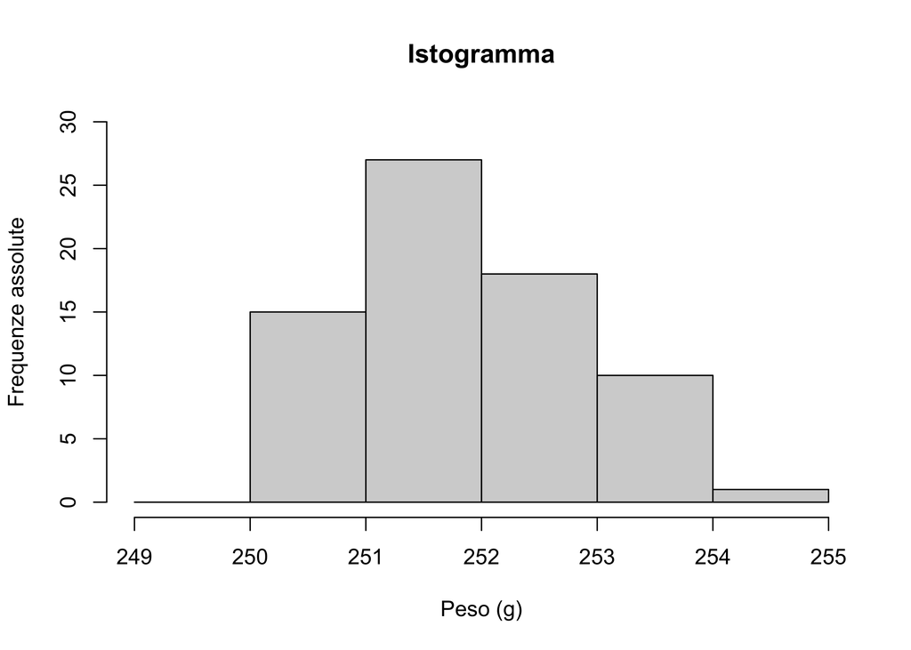

I pacchetti di burro che pesano al più $252 g$ sono $F(252) = 42$.

### Esercizio B

L’unità statistica è la pagina del libro. Il numero di errori di stampa per pagina è una variabile quantitativa discreta, poiché assume valori interi.

Ricordando la definizione di funzione di ripartizione empirica:
$$F(x) = \frac{1}{n} \sum_{i=1}^n \mathbb{I}(x_i \leq x),$$
possiamo quindi ottenere la seguente tabella:

| Valore | $F(x)$ |
| --- | --- |
| 0 | 112/280 = 0.4 |
| 1 | 200/280 = 0.714 |
| 2 | 244/280 = 0.871 |
| 3 | 262/280 = 0.936 |
| 4 | 272/280 = 0.971 |
| 5 | 1 |

La cui rappresentazione grafica è data da:

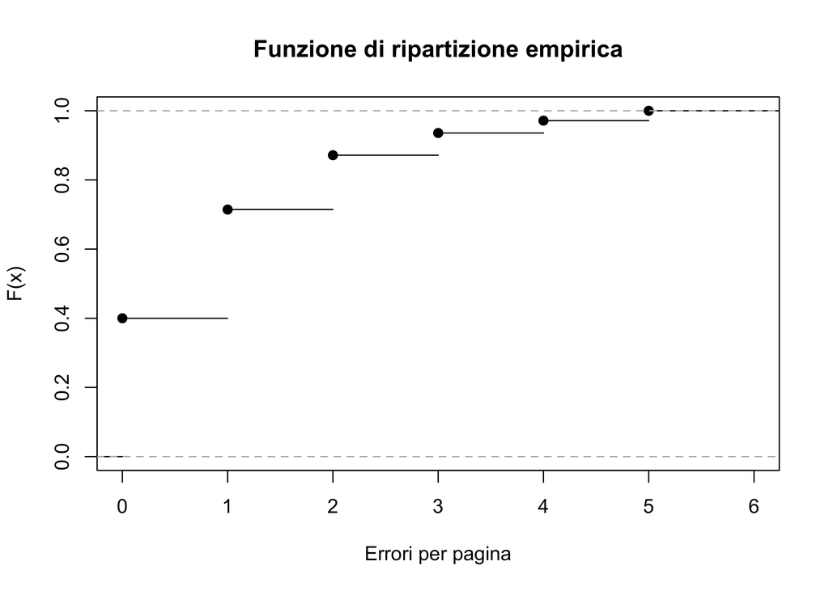

I risultati sono arrotondati a tre cifre decimali. La proporzione di pagine con meno di tre errori è $F(2) = 0.871$, mentre $F(3) = 0.936$, come visibile dalla tabella precedente.

### Esercizio E

$$y = (0.22,\:-0.64,\: -0.60,\: -0.89,\: -1.56,\: 0.79,\: -0.50,\: -2.97,\: -0.30,\: -1.47)$$
e
$$x = (-0.56,\: -0.23,\: 1.56,\: 0.07,\: 0.13,\: 1.72,\: 0.46,\: -1.27,\: -0.69,\: -0.45),$$

Inoltre, si ottiene che:

$$F_x(0) = \frac{1}{10} \sum_{i=1}^{10} \mathbb{I}(x_i \leq 0) = 0.5$$
$$F_x(2) = \frac{1}{10} \sum_{i=1}^{10} \mathbb{I}(x_i \leq 2) = 1$$
$$\min(y) = -2.97, \quad \max(y) = 0.79.$$